# Data exploration and basic plotting

Elizabeth Oladapo

[figure not shown]

In this section, we will focus on loading data into R and saving files into your project directory and sub directories, exploring data and basic plotting of graphs.

### 1. Download the datasets

Download the datasets we will be using in this training:

ElephantsMF.csv

IRIS.csv

Move the two .csv files into the data folder in your project folder (“R-training”) on your local machine

### 2. Importing data from the data folder into R

Any .csv file can be imported into R using the function read_csv() and assigning it to a new variable to store the result.

Prior to loading your data, make sure to load the required libraries for this section and set up you script with appropriate annotations

**Something to note**: Always annotate your code (with # and break into sections with # and ——) so that when you look back on what you have coded. You understand in detail what a line, chunk or even section of code is trying to accomplish.

```r
### Data Management and Basic graphing (* you can create a section or chapter by putting "----" @ the end of this line)
### Elizabeth Oladapo
### 13 February 2023

# Analyzing the data on 288 African elephants that lived through droughts in the first two years of life.
# The data contains 3 variables and 288 observations.
# The variables are; Age, Height and sex

##Source:
# Data are from Phyllis Lee, Stirling University, and are related to Lee, P., et al. (2013), "Enduring consequences of early
# experiences: 40-year effects on survival and success among African elephants," Biology Letters, 9:
# 20130011.



# Load the packages I need with the function library()

library("tidyverse") #tidyverse imports ggplot2 and dplyr
```

A check can be performed with the function file.exists() which will print TRUE if the file is present in the working directory.

```r
file.exists("data/ElephantsMF.csv")
```

```
[1] TRUE
```

Now that the file exists in the working directory, we will need to import it into R to start making R work hard on it.

Import the ElephantsMF.csv file and assign it to a variable name called “Elephants_data”

```r
# Loading the required data

Elephants_data <- read_csv("data/ElephantsMF.csv")
```

Look at the data using the function glimpse(), to be sure you have loaded the correct data

```r
# Looking at the data

glimpse(Elephants_data)
```

```
Rows: 288
Columns: 3
$ Age    <dbl> 1.40, 17.50, 12.75, 11.17, 12.67, 12.67, 12.25, 12.17, 28.17, 11.67, 16.33, 12.58, 25.42, 12.42…
$ Height <dbl> 120.00, 227.00, 235.00, 210.00, 220.00, 189.00, 225.00, 204.00, 265.85, 233.00, 241.00, 212.00,…
$ Sex    <chr> "M", "M", "M", "M", "M", "M", "M", "M", "M", "M", "M", "M", "M", "M", "M", "M", "M", "M", "M", …
```

```r
# or just Elephants_data
# or use "str(Elephants_data)"  to show the 'factors' and 'levels' info in output for characters.
# Some R version will require that you convert the character variable to factor as seen below,
# for str() to show "factors" info.
# str(Elephants_data,stringsAsFactors=TRUE)
# Elephants_data$Sex <- as.factor(Elephants_data$Sex)
```

```
Question 1
There are three variables in the Elephants_data, which of them are the explanatory variables and which is a response variable?
```

### 3. Visualizing data

Visualize the data by generating your first plot in R using the function ggplot() from the package, ggplot2.

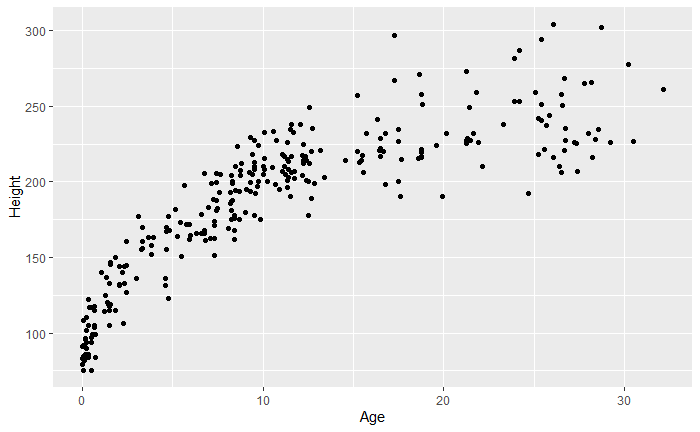

```r
## Visualize the data1

ggplot(Elephants_data, aes(x = Age, y=Height))+
  geom_point()    # a continuous response variable with a continuous explanatory variable producing scatterplot
```

```
Question 2.

What is the relatioship between height and age? any interaction with age groups (below 20 and above 20)?
```

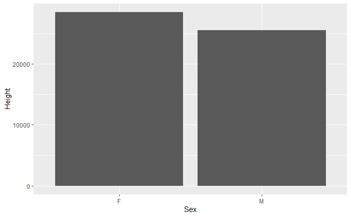

```r
## Visualizing the data

ggplot(Elephants_data, aes(x = Sex, y=Height))+
  geom_col()    # a continuous response variable with a binary explanatory variable producing barcharts
```

### 4. Customizing the plot

We can put additional arguments in the aesthetics to customize plot. For example, to see that there are two groups in the data, we will add colour and shape to our the aesthetic.

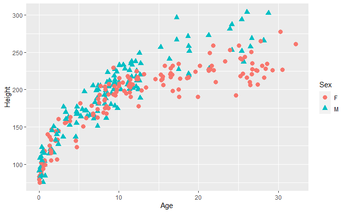

```r
## Visualizing the data

ggplot(Elephants_data, aes(x = Age, y=Height, colour = Sex, shape= Sex))+
  geom_point(size = 3)    # a continuous response variable with a continuous explanatory variable producing scatterplot
```

```r
NA
NA
NA
```

### 5. Manipulating data

We can use several functions in the package, dplyr to explore and manipulate the data.

Please note that it is possible to use the functions in the The [R Base Package](https://stat.ethz.ch/R-manual/R-devel/library/base/html/00Index.html) (This package contains the basic functions which makes R a language: arithmetic, input/output, basic programming support, etc. Its contents are available through inheritance from any environment.). However, it is generally easier to read, manipulate and write data using dplyr.

We will be covering some of the functions available in the dplyr here. However, you can get an overview of most functions in dplyr [cheatsheet](https://www.rstudio.com/wp-content/uploads/2015/02/data-wrangling-cheatsheet.pdf).

**Note:** Mostly, observations are in the rows and variables are in the columns

We can access the columns of a data frame using the select function.

**Subsetting Variables: Columns**

The variables in our data are Age, Height and Sex as you can see in the environment pane or using the function glimpse().

“select()” from dplyr grabs specific columns and works only with variables

We can select column by name, by adding bare column names (i.e. not requiring quote marks around the name) after the name of the data frame, separated by a , .

Make sure to type the name exactly as it appears in the data. If select sees a name that doesn’t exist in the data frame it will give an informative message Error.

Again, check what select does from the [cheatsheet](https://www.rstudio.com/wp-content/uploads/2015/02/data-wrangling-cheatsheet.pdf).

```r
## subsetting columns
# select the "Age" variable from the Elephants_data

select(Elephants_data, Age)
```

| Age |
| --- |
| 1.40 |
| 17.50 |
| 12.75 |
| 11.17 |
| 12.67 |
| 12.67 |
| 12.25 |
| 12.17 |
| 28.17 |
| 11.67 |

[output cut: 278 more lines]

```r
NA
```

Columns can also be omitted from the output by putting a minus (-) in front of the column name.

```r
## subsetting columns
# Omitting the "Age" variable from the Elephants_data

select(Elephants_data, -Age)
```

| Height | Sex |
| --- | --- |
| 120.00 | M |
| 227.00 | M |
| 235.00 | M |
| 210.00 | M |
| 220.00 | M |
| 189.00 | M |
| 225.00 | M |
| 204.00 | M |
| 265.85 | M |
| 233.00 | M |

[output cut: 278 more lines]

```r
NA
```

We can select a range of variables by the : operator.

```r
## subsetting columns
# selecting the variables from "Height" to "Sex" in the Elephants_data

select(Elephants_data, Height:Sex)
```

| Height | Sex |
| --- | --- |
| 120.00 | M |
| 227.00 | M |
| 235.00 | M |
| 210.00 | M |
| 220.00 | M |
| 189.00 | M |
| 225.00 | M |
| 204.00 | M |
| 265.85 | M |
| 233.00 | M |

[output cut: 278 more lines]

```r
NA
```

Helper functions can be utilized to avoid writing the exact names of the column.

```r
## subsetting columns
# selecting the variables with colnames starting with "He"

select(Elephants_data, starts_with("He"))
```

| Height |
| --- |
| 120.00 |
| 227.00 |
| 235.00 |
| 210.00 |
| 220.00 |
| 189.00 |
| 225.00 |
| 204.00 |
| 265.85 |
| 233.00 |

[output cut: 278 more lines]

```r
# selecting the variables with colnames starting with "ex"
select(Elephants_data, contains("ge"))
```

| Age |
| --- |
| 1.40 |
| 17.50 |
| 12.75 |
| 11.17 |
| 12.67 |
| 12.67 |
| 12.25 |
| 12.17 |
| 28.17 |
| 11.67 |

[output cut: 278 more lines]

```r
# selecting the last column
select(Elephants_data, last_col())
```

| Sex |
| --- |
| M |
| M |
| M |
| M |
| M |
| M |
| M |
| M |
| M |
| M |

[output cut: 278 more lines]

```r
NA
```

There is a different way to get columns with dplyr functions instead of nesting the verbs: Use piping operator ” %>% “. Piping is a magical and fast way to do multiple things with dataframe.

Please, use the piping from now on!

```r
Elephants_data %>%
  select(., Age)
```

| Age |
| --- |
| 1.40 |
| 17.50 |
| 12.75 |
| 11.17 |
| 12.67 |
| 12.67 |
| 12.25 |
| 12.17 |
| 28.17 |
| 11.67 |

[output cut: 278 more lines]

```r
#instead of "select(Elephants_data, Age)"
```

We can select more than one variables

```r
# Selecting more than one variables

Elephants_data %>%
  select(., Age, Height)
```

| Age | Height |
| --- | --- |
| 1.40 | 120.00 |
| 17.50 | 227.00 |
| 12.75 | 235.00 |
| 11.17 | 210.00 |
| 12.67 | 220.00 |
| 12.67 | 189.00 |
| 12.25 | 225.00 |
| 12.17 | 204.00 |
| 28.17 | 265.85 |
| 11.67 | 233.00 |

[output cut: 278 more lines]

```r
# Remember that you can also select out the variable you don't want instead of selecting a list of variables if you have a large data.
```

It is also possible to use the column number in the selection.

```r
Elephants_data %>%
  select(., 1:2)
```

| Age | Height |
| --- | --- |
| 1.40 | 120.00 |
| 17.50 | 227.00 |
| 12.75 | 235.00 |
| 11.17 | 210.00 |
| 12.67 | 220.00 |
| 12.67 | 189.00 |
| 12.25 | 225.00 |
| 12.17 | 204.00 |
| 28.17 | 265.85 |
| 11.67 | 233.00 |

[output cut: 278 more lines]

```r
NA
```

You can select a variable from a dataframe and assign it to an object / a new dataframe

```r
Elephant_Subset <- Elephants_data %>%
  select(., Age, Height)
```

**Subsetting Observations: Rows**

“filter()” from dplyr can be used to subset rows of the dataframes when we need to extract particular observations from the data. Don’t forget about the [cheatsheet](https://www.rstudio.com/wp-content/uploads/2015/02/data-wrangling-cheatsheet.pdf).

The usage of filter(), involves using logical operations

x < y: is x less than y?

x > y: is x greater than y?

x == y: equal to (not this is double “equal to” sign, not single)

x != y: not equal to

We can use these logical operators to perform logical tests to filter the rows in a data frame. This logical test will be applied to each row and give either a TRUE or FALSE result. When filtering, only rows with a TRUE result get returned.

For example, we can filter for rows where the “Height” variable is less than 200.

[output not shown]

[output cut: 278 more lines]

**Something to try:** Filter for rows where the “Age” variable is greater than and equal to 12.8

### 6. Exercises

**A**

Tips:

• select the Height and Age columns

• filter Age that is < 15

• assign the data subset an object named EL_Age_15

• look at the data

• produce a scatterplot of Height (x) versus Age (y), proving that there are only age values < 15

### 7. Save your results and script!

[output not shown]

**Congratulations on your first script in R, we are now ready for the next stage**

**Return** to the [main course page:](https://lizzydapsy.github.io/R-for-Data-Analysis/README.html) and click on “Data manipulation and advanced plotting”.